# Телеком: прогноз оттока клиентов

Оператор связи «ТелеДом» хочет бороться с оттоком клиентов. Для этого его сотрудники начнут предлагать промокоды и специальные условия всем, кто планирует отказаться от услуг связи. Чтобы заранее находить таких пользователей, «ТелеДому» нужна модель, которая будет предсказывать, разорвёт ли абонент договор. Команда оператора собрала персональные данные о некоторых клиентах, информацию об их тарифах и услугах.

**Цель исследования** - научиться выявлять клиентов, которые планируют отказаться от услуг компании «ТелеДом», чтобы избежать финансовых потерь. Сохранить старых клиентов дешевле, чем привлечь новых.

**Моя задача** — обучить на этих данных модель для прогноза оттока клиентов, найти признаки-индикаторы оттока клиентов.

*Кратко об услугах компании:*

- Два основных типа услуг:
  - Стационарную телефонную связь. Телефон можно подключить к нескольким линиям одновременно.
  - Интернет. Подключение может быть двух типов: через телефонную линию (DSL, от англ. digital subscriber line — «цифровая абонентская линия») или оптоволоконный кабель (Fiber optic).
- Дополнительные услуги:
  - Интернет-безопасность: антивирус (DeviceProtection) и блокировка небезопасных сайтов (OnlineSecurity);
  - Выделенная линия технической поддержки (TechSupport);
  - Облачное хранилище файлов для резервного копирования данных (OnlineBackup);
  - Стриминговое телевидение (StreamingTV) и каталог фильмов (StreamingMovies).

Клиенты могут платить за услуги каждый месяц или заключить договор на 1–2 года. Возможно оплатить счёт разными способами, а также получить электронный чек.

Получены данные для исследования в нескольких таблицах:

- `contract_new.csv` — информация о договоре;
- `personal_new.csv` — персональные данные клиента;
- `internet_new.csv` — информация об интернет-услугах;
- `phone_new.csv` — информация об услугах телефонии.

Исследование пройдет в несколько этапов:

1. Обзор данных
2. Предобработка данных
3. Разведочный анализ данных
4. Подготовка данных к МО и подбор модели
5. Итоговый вывод и рекомендации

# 1.Обзор данных

## 1.1 Информация о договоре

```python
import os
import pandas as pd
import matplotlib.pyplot as plt
import seaborn as sns
import numpy as np
import phik
import shap
import plotly.express as px

from sklearn.model_selection import train_test_split, RandomizedSearchCV, cross_val_score, StratifiedKFold
from sklearn.linear_model import LogisticRegression
from sklearn.preprocessing import OneHotEncoder , StandardScaler, MinMaxScaler, OrdinalEncoder
from sklearn.impute import SimpleImputer
from sklearn.metrics import roc_auc_score, accuracy_score, confusion_matrix, ConfusionMatrixDisplay
from sklearn.pipeline import Pipeline
from sklearn.compose import ColumnTransformer
from sklearn.tree import DecisionTreeClassifier
from sklearn.svm import SVC
from sklearn.neighbors import KNeighborsClassifier
import lightgbm as lgb
from sklearn.dummy import DummyClassifier
from sklearn.feature_selection import SelectKBest
from optuna_integration import OptunaSearchCV
from optuna.distributions import IntDistribution as intd, FloatDistribution as fl, CategoricalDistribution as CatDist

from datetime import date
from dateutil.relativedelta import relativedelta

%matplotlib inline
RANDOM_STATE = 180324
sns.set_palette("pastel")
pd.set_option('display.max_columns', None)
shap.initjs()
```

```python
pth_local1 = 'contract_new.csv'
pth_local2 = 'personal_new.csv'
pth_local3 = 'internet_new.csv'
pth_local4 = 'phone_new.csv'

pth1 = '/datasets/contract_new.csv'
pth2 = '/datasets/personal_new.csv'
pth3 = '/datasets/internet_new.csv'
pth4 = '/datasets/phone_new.csv'

if os.path.exists(pth_local1) and os.path.exists(pth_local2) and os.path.exists(pth_local3) and os.path.exists(pth_local4):
    contract = pd.read_csv(pth_local1, parse_dates = ['BeginDate', 'EndDate'], index_col='customerID')
    personal = pd.read_csv(pth_local2, index_col='customerID')
    internet = pd.read_csv(pth_local3, index_col='customerID')
    phone = pd.read_csv(pth_local4, index_col='customerID')
elif os.path.exists(pth1) and os.path.exists(pth2) and os.path.exists(pth3) and os.path.exists(pth4):
    contract = pd.read_csv(pth1, parse_dates = ['BeginDate', 'EndDate'], index_col='customerID')
    personal = pd.read_csv(pth2, index_col='customerID')
    internet = pd.read_csv(pth3,index_col='customerID')
    phone = pd.read_csv(pth4, index_col='customerID')
else:
    print('Something is wrong')
```

```python
contract.sample(5)
```

| customerID | BeginDate | EndDate | Type | PaperlessBilling | PaymentMethod | MonthlyCharges | TotalCharges |
| --- | --- | --- | --- | --- | --- | --- | --- |
| 6654-QGBZZ | 2020-01-01 | No | Month-to-month | No | Mailed check | 19.90 | 21.49 |
| 6344-SFJVH | 2018-06-01 | No | Month-to-month | No | Credit card (automatic) | 24.90 | 498.0 |
| 2533-TIBIX | 2018-11-01 | No | Month-to-month | Yes | Bank transfer (automatic) | 30.20 | 453.0 |
| 8752-STIVR | 2019-07-01 | No | Month-to-month | Yes | Electronic check | 79.00 | 553.0 |
| 0257-KXZGU | 2017-06-01 | No | Month-to-month | No | Bank transfer (automatic) | 62.45 | 1998.4 |

```python
contract.info()
```

```
<class 'pandas.core.frame.DataFrame'>
Index: 7043 entries, 7590-VHVEG to 3186-AJIEK
Data columns (total 7 columns):
 #   Column            Non-Null Count  Dtype
---  ------            --------------  -----
 0   BeginDate         7043 non-null   datetime64[ns]
 1   EndDate           7043 non-null   object
 2   Type              7043 non-null   object
 3   PaperlessBilling  7043 non-null   object
 4   PaymentMethod     7043 non-null   object
 5   MonthlyCharges    7043 non-null   float64
 6   TotalCharges      7043 non-null   object
dtypes: datetime64[ns](1), float64(1), object(5)
memory usage: 440.2+ KB
```

```python
contract.describe(include='all')
```

|  | BeginDate | EndDate | Type | PaperlessBilling | PaymentMethod | MonthlyCharges | TotalCharges |
| --- | --- | --- | --- | --- | --- | --- | --- |
| count | 7043 | 7043 | 7043 | 7043 | 7043 | 7043.000000 | 7043 |
| unique | NaN | 67 | 3 | 2 | 4 | NaN | 6658 |
| top | NaN | No | Month-to-month | Yes | Electronic check | NaN |  |
| freq | NaN | 5942 | 3875 | 4171 | 2365 | NaN | 11 |
| mean | 2017-04-30 13:01:50.918642688 | NaN | NaN | NaN | NaN | 64.761692 | NaN |
| min | 2013-10-01 00:00:00 | NaN | NaN | NaN | NaN | 18.250000 | NaN |
| 25% | 2015-06-01 00:00:00 | NaN | NaN | NaN | NaN | 35.500000 | NaN |
| 50% | 2017-09-01 00:00:00 | NaN | NaN | NaN | NaN | 70.350000 | NaN |
| 75% | 2019-04-01 00:00:00 | NaN | NaN | NaN | NaN | 89.850000 | NaN |
| max | 2020-02-01 00:00:00 | NaN | NaN | NaN | NaN | 118.750000 | NaN |
| std | NaN | NaN | NaN | NaN | NaN | 30.090047 | NaN |

```python
contract[contract.TotalCharges == ' ']
```

| customerID | BeginDate | EndDate | Type | PaperlessBilling | PaymentMethod | MonthlyCharges | TotalCharges |
| --- | --- | --- | --- | --- | --- | --- | --- |
| 4472-LVYGI | 2020-02-01 | No | Two year | Yes | Bank transfer (automatic) | 52.55 |  |
| 3115-CZMZD | 2020-02-01 | No | Two year | No | Mailed check | 20.25 |  |
| 5709-LVOEQ | 2020-02-01 | No | Two year | No | Mailed check | 80.85 |  |
| 4367-NUYAO | 2020-02-01 | No | Two year | No | Mailed check | 25.75 |  |
| 1371-DWPAZ | 2020-02-01 | No | Two year | No | Credit card (automatic) | 56.05 |  |
| 7644-OMVMY | 2020-02-01 | No | Two year | No | Mailed check | 19.85 |  |
| 3213-VVOLG | 2020-02-01 | No | Two year | No | Mailed check | 25.35 |  |
| 2520-SGTTA | 2020-02-01 | No | Two year | No | Mailed check | 20.00 |  |
| 2923-ARZLG | 2020-02-01 | No | One year | Yes | Mailed check | 19.70 |  |
| 4075-WKNIU | 2020-02-01 | No | Two year | No | Mailed check | 73.35 |  |
| 2775-SEFEE | 2020-02-01 | No | Two year | Yes | Bank transfer (automatic) | 61.90 |  |

```python
contract.TotalCharges.value_counts().head(10)
```

```
TotalCharges
          11
20.45      6
101.0      5
21.53      4
40.1       4
255.0      4
19.65      4
732.6      4
1007.5     4
1155.0     3
Name: count, dtype: int64
```

```python
contract[contract.BeginDate == '2020-02-01']
```

| customerID | BeginDate | EndDate | Type | PaperlessBilling | PaymentMethod | MonthlyCharges | TotalCharges |
| --- | --- | --- | --- | --- | --- | --- | --- |
| 4472-LVYGI | 2020-02-01 | No | Two year | Yes | Bank transfer (automatic) | 52.55 |  |
| 3115-CZMZD | 2020-02-01 | No | Two year | No | Mailed check | 20.25 |  |
| 5709-LVOEQ | 2020-02-01 | No | Two year | No | Mailed check | 80.85 |  |
| 4367-NUYAO | 2020-02-01 | No | Two year | No | Mailed check | 25.75 |  |
| 1371-DWPAZ | 2020-02-01 | No | Two year | No | Credit card (automatic) | 56.05 |  |
| 7644-OMVMY | 2020-02-01 | No | Two year | No | Mailed check | 19.85 |  |
| 3213-VVOLG | 2020-02-01 | No | Two year | No | Mailed check | 25.35 |  |
| 2520-SGTTA | 2020-02-01 | No | Two year | No | Mailed check | 20.00 |  |
| 2923-ARZLG | 2020-02-01 | No | One year | Yes | Mailed check | 19.70 |  |
| 4075-WKNIU | 2020-02-01 | No | Two year | No | Mailed check | 73.35 |  |
| 2775-SEFEE | 2020-02-01 | No | Two year | Yes | Bank transfer (automatic) | 61.90 |  |

## 1.2 Персональные данные клиентов

```python
personal.sample(5)
```

| customerID | gender | SeniorCitizen | Partner | Dependents |
| --- | --- | --- | --- | --- |
| 7354-OIJLX | Male | 0 | No | No |
| 1271-SJBGZ | Male | 1 | No | No |
| 9522-BNTHX | Female | 1 | No | No |
| 7980-MHFLQ | Female | 0 | Yes | Yes |
| 7742-MYPGI | Female | 0 | Yes | Yes |

```python
personal.info()
```

```
<class 'pandas.core.frame.DataFrame'>
Index: 7043 entries, 7590-VHVEG to 3186-AJIEK
Data columns (total 4 columns):
 #   Column         Non-Null Count  Dtype
---  ------         --------------  -----
 0   gender         7043 non-null   object
 1   SeniorCitizen  7043 non-null   int64
 2   Partner        7043 non-null   object
 3   Dependents     7043 non-null   object
dtypes: int64(1), object(3)
memory usage: 275.1+ KB
```

```python
personal.describe(include='all')
```

|  | gender | SeniorCitizen | Partner | Dependents |
| --- | --- | --- | --- | --- |
| count | 7043 | 7043.000000 | 7043 | 7043 |
| unique | 2 | NaN | 2 | 2 |
| top | Male | NaN | No | No |
| freq | 3555 | NaN | 3641 | 4933 |
| mean | NaN | 0.162147 | NaN | NaN |
| std | NaN | 0.368612 | NaN | NaN |
| min | NaN | 0.000000 | NaN | NaN |
| 25% | NaN | 0.000000 | NaN | NaN |
| 50% | NaN | 0.000000 | NaN | NaN |
| 75% | NaN | 0.000000 | NaN | NaN |
| max | NaN | 1.000000 | NaN | NaN |

### Микровывод:

1. В персональных данных есть информация о:
- `customerID` — идентификатор пользователя;
- `gender` — пол;
- `SeniorCitizen` — является ли абонент пенсионером;
- `Partner` — есть ли у абонента супруг или супруга;
- `Dependents` — есть ли у абонента дети.
1. Пропусков снова нет.
2. Каждый признак (кроме идентификатора) в таблице бинарный.

## 1.3 Информация об интернет-услугах

```python
internet.sample(5)
```

| customerID | InternetService | OnlineSecurity | OnlineBackup | DeviceProtection | TechSupport | StreamingTV | StreamingMovies |
| --- | --- | --- | --- | --- | --- | --- | --- |
| 4837-PZTIC | DSL | Yes | No | Yes | Yes | No | No |
| 8791-GFXLZ | DSL | No | Yes | No | No | No | No |
| 7927-AUXBZ | Fiber optic | No | No | No | Yes | Yes | No |
| 4374-YMUSQ | Fiber optic | Yes | Yes | Yes | Yes | Yes | Yes |
| 4002-BQWPQ | DSL | Yes | Yes | Yes | Yes | No | Yes |

```python
internet.info()
```

```
<class 'pandas.core.frame.DataFrame'>
Index: 5517 entries, 7590-VHVEG to 3186-AJIEK
Data columns (total 7 columns):
 #   Column            Non-Null Count  Dtype
---  ------            --------------  -----
 0   InternetService   5517 non-null   object
 1   OnlineSecurity    5517 non-null   object
 2   OnlineBackup      5517 non-null   object
 3   DeviceProtection  5517 non-null   object
 4   TechSupport       5517 non-null   object
 5   StreamingTV       5517 non-null   object
 6   StreamingMovies   5517 non-null   object
dtypes: object(7)
memory usage: 344.8+ KB
```

```python
internet.describe(include='all')
```

|  | InternetService | OnlineSecurity | OnlineBackup | DeviceProtection | TechSupport | StreamingTV | StreamingMovies |
| --- | --- | --- | --- | --- | --- | --- | --- |
| count | 5517 | 5517 | 5517 | 5517 | 5517 | 5517 | 5517 |
| unique | 2 | 2 | 2 | 2 | 2 | 2 | 2 |
| top | Fiber optic | No | No | No | No | No | No |
| freq | 3096 | 3498 | 3088 | 3095 | 3473 | 2810 | 2785 |

### Микровывод:

1. Характеристики, описывающие интернет-услуги:
- `customerID` — идентификатор пользователя;
- `InternetService` — тип подключения;
- `OnlineSecurity` — блокировка опасных сайтов;
- `OnlineBackup` — облачное хранилище файлов для резервного копирования данных;
- `DeviceProtection` — антивирус;
- `TechSupport` — выделенная линия технической поддержки;
- `StreamingTV` — стриминговое телевидение;
- `StreamingMovies` — каталог фильмов.
1. Записей меньше, чем в предыдущих таблицах, т.к. не все клиенты пользуются интернет услугами компании, кого-то интересует только телефонная связь.
2. Все признаки (кроме идентификатора) бинарные.

## 1.4 Услуги телефонии

```python
phone.sample(5)
```

| customerID | MultipleLines |
| --- | --- |
| 3966-HRMZA | No |
| 2860-RANUS | Yes |
| 4423-JWZJN | Yes |
| 6134-KWTBV | Yes |
| 1702-CCFNJ | Yes |

```python
phone.info()
```

```
<class 'pandas.core.frame.DataFrame'>
Index: 6361 entries, 5575-GNVDE to 3186-AJIEK
Data columns (total 1 columns):
 #   Column         Non-Null Count  Dtype
---  ------         --------------  -----
 0   MultipleLines  6361 non-null   object
dtypes: object(1)
memory usage: 99.4+ KB
```

```python
phone.describe()
```

|  | MultipleLines |
| --- | --- |
| count | 6361 |
| unique | 2 |
| top | No |
| freq | 3390 |

### Микровывод:

1. Признаки в данной таблице:
- `customerID` — идентификатор пользователя;
- `MultipleLines` — подключение телефона к нескольким линиям одновременно.
1. Не все клиенты компании пользуются услугами телефонии.

## 1.5 Вывод по обзору

- Информация представлена в 4 таблицах. Данные соответствуют описанию задачи.
- Всего для исследования предоставлены данные 7043 клиентов компании, некоторые пользуются только интернет услугами, другие - услугами телефонии.
- Есть клиенты, которые только начали пользоваться услугами компании - договор от 1 февраля 2020 (дата выгрузки данных).

# 2. Предобработка данных

## 2.1 Пропуски

Есть небольшое число пропусков в таблице `contract` в колонке `TotalCharges`.

Пропуски характерные для клиентов, которые только пришли в компанию и еще ничего не заплатили. Поэтому поставим 0 на месте пропусков.

```python
contract['TotalCharges'] = contract['TotalCharges'].apply(lambda x: 0 if x == ' ' else x)
```

```python
contract[contract.TotalCharges == 0]
```

| customerID | BeginDate | EndDate | Type | PaperlessBilling | PaymentMethod | MonthlyCharges | TotalCharges |
| --- | --- | --- | --- | --- | --- | --- | --- |
| 4472-LVYGI | 2020-02-01 | No | Two year | Yes | Bank transfer (automatic) | 52.55 | 0 |
| 3115-CZMZD | 2020-02-01 | No | Two year | No | Mailed check | 20.25 | 0 |
| 5709-LVOEQ | 2020-02-01 | No | Two year | No | Mailed check | 80.85 | 0 |
| 4367-NUYAO | 2020-02-01 | No | Two year | No | Mailed check | 25.75 | 0 |
| 1371-DWPAZ | 2020-02-01 | No | Two year | No | Credit card (automatic) | 56.05 | 0 |
| 7644-OMVMY | 2020-02-01 | No | Two year | No | Mailed check | 19.85 | 0 |
| 3213-VVOLG | 2020-02-01 | No | Two year | No | Mailed check | 25.35 | 0 |
| 2520-SGTTA | 2020-02-01 | No | Two year | No | Mailed check | 20.00 | 0 |
| 2923-ARZLG | 2020-02-01 | No | One year | Yes | Mailed check | 19.70 | 0 |
| 4075-WKNIU | 2020-02-01 | No | Two year | No | Mailed check | 73.35 | 0 |
| 2775-SEFEE | 2020-02-01 | No | Two year | Yes | Bank transfer (automatic) | 61.90 | 0 |

## 2.2 Дубликаты

- дубликаты строк

```python
tables = [contract, personal, internet, phone]
```

```python
for table in tables:
    print(table.duplicated().sum())
```

```
37
7027
5389
6359
```

Дубликатов ID нет, строки без ID в таблицах повторяются, но это нормально, т.к. данные приведенные в таблицах не слишком индивидуальны и могут быть одинаковыми для разных клиентов.

- проверим наличие ошибок в названиях категорий типов оплаты и типов платежей (остальные категоиральные признаки бинарные, видели в обзоре, там ошибок точно нет)

```python
print('Значения типов оплаты по договору:')
print(tables[0].Type.value_counts())

print('Значения типов платежей:')
print(tables[0].PaymentMethod.value_counts())
```

```
Значения типов оплаты по договору:
Type
Month-to-month    3875
Two year          1695
One year          1473
Name: count, dtype: int64
Значения типов платежей:
PaymentMethod
Electronic check             2365
Mailed check                 1612
Bank transfer (automatic)    1544
Credit card (automatic)      1522
Name: count, dtype: int64
```

## 2.3 Изменение типов данных и добавление признаков

**Даты (начало и конец периода обслуживания клиента):**

- Добавим дату выгрузки данных в столбец `EndDate_all` неушедших пользователей и перенесем соответствующую дату для ушедших. Затем в столбцы с длительностью (по месяцам, дням, годам) добавим инфо про неушедших клиентов.
- Добавим признаки: длительность договора в годах, в днях и в месяцах для всех клиентов,для ушедших - это окончательное число, для нынешних - длительность пользования на момент выгрузки данных.

```python
contract.BeginDate.value_counts().head()
```

```
BeginDate
2014-02-01    366
2019-10-01    237
2019-11-01    237
2019-09-01    237
2020-01-01    233
Name: count, dtype: int64
```

```python
contract.EndDate.value_counts().head()
```

```
EndDate
No            5942
2020-01-01      39
2019-12-01      38
2018-11-01      35
2019-09-01      32
Name: count, dtype: int64
```

```python
contract['EndDate_all'] = contract['EndDate'].apply(lambda x: x if x!='No' else '2020-02-01')
contract['EndDate_all'] = pd.to_datetime(contract['EndDate_all']).dt.date
contract['BeginDate'] = pd.to_datetime(contract['BeginDate']).dt.date
```

```python
def calculate_year_difference(row):
    '''
    Функция принимает ряд датасета и вычисляет разницу между датой начала контракта и конца контракта в годах
    '''
    return relativedelta(row['EndDate_all'], row['BeginDate']).years


def calculate_month_difference(row):
    '''
    Функция принимает ряд датасета и вычисляет разницу между датой начала контракта и конца контракта в месяцах e
    '''
    return (relativedelta(row['EndDate_all'], row['BeginDate']).years * 12) + relativedelta(row['EndDate_all'], row['BeginDate']).months


def calculate_day_difference(row):
    '''
    Функция принимает ряд датасета и вычисляет разницу (количество дней) между датой начала контракта и конца контракта
    '''
    return (row['EndDate_all'] - row['BeginDate']).days

contract['year_duration'] = (contract.apply(calculate_year_difference, axis=1)).astype('object')
contract['month_duration'] = contract.apply(calculate_month_difference, axis=1)
contract['day_duration'] = contract.apply(calculate_day_difference, axis=1)
```

```python
contract.sample(15)
```

| customerID | BeginDate | EndDate | Type | PaperlessBilling | PaymentMethod | MonthlyCharges | TotalCharges | EndDate_all | year_duration | month_duration | day_duration |
| --- | --- | --- | --- | --- | --- | --- | --- | --- | --- | --- | --- |
| 1635-FJFCC | 2019-09-01 | No | Month-to-month | Yes | Credit card (automatic) | 44.05 | 220.25 | 2020-02-01 | 0 | 5 | 153 |
| 4662-EKDPQ | 2019-08-01 | No | Month-to-month | No | Bank transfer (automatic) | 62.05 | 390.91 | 2020-02-01 | 0 | 6 | 184 |
| 7880-XSOJX | 2019-10-01 | No | Month-to-month | No | Mailed check | 42.40 | 186.56 | 2020-02-01 | 0 | 4 | 123 |
| 8046-DNVTL | 2014-12-01 | 2017-07-01 | Two year | Yes | Credit card (automatic) | 38.60 | 1292.33 | 2017-07-01 | 2 | 31 | 943 |
| 5092-STPKP | 2018-02-01 | No | Month-to-month | No | Credit card (automatic) | 56.35 | 1365.92 | 2020-02-01 | 2 | 24 | 730 |
| 9938-ZREHM | 2017-01-01 | No | One year | No | Mailed check | 72.10 | 2881.12 | 2020-02-01 | 3 | 37 | 1126 |
| 6196-HBOBZ | 2014-09-01 | No | Two year | Yes | Electronic check | 99.35 | 6457.75 | 2020-02-01 | 5 | 65 | 1979 |
| 9668-PUGNU | 2014-03-01 | No | Two year | Yes | Electronic check | 24.50 | 1861.27 | 2020-02-01 | 5 | 71 | 2163 |
| 1976-CFOCS | 2019-12-01 | No | Month-to-month | No | Electronic check | 46.00 | 99.36 | 2020-02-01 | 0 | 2 | 62 |
| 8357-EQXFO | 2019-04-01 | No | Month-to-month | Yes | Electronic check | 95.35 | 953.5 | 2020-02-01 | 0 | 10 | 306 |
| 5170-PTRKA | 2016-01-01 | No | One year | Yes | Credit card (automatic) | 35.80 | 1754.2 | 2020-02-01 | 4 | 49 | 1492 |
| 5214-NLTIT | 2014-02-01 | No | Two year | Yes | Credit card (automatic) | 90.80 | 6537.6 | 2020-02-01 | 6 | 72 | 2191 |
| 1689-MRZQR | 2017-02-01 | No | Month-to-month | No | Electronic check | 78.30 | 2818.8 | 2020-02-01 | 3 | 36 | 1095 |
| 2235-EZAIK | 2014-02-01 | No | Two year | No | Credit card (automatic) | 79.20 | 6101.57 | 2020-02-01 | 6 | 72 | 2191 |
| 3500-RMZLT | 2018-08-01 | No | Month-to-month | Yes | Mailed check | 96.30 | 1733.4 | 2020-02-01 | 1 | 18 | 549 |

- остальные

```python
personal['SeniorCitizen'] = personal['SeniorCitizen'].astype('object')

print(personal.info())

personal.head()
```

```
<class 'pandas.core.frame.DataFrame'>
Index: 7043 entries, 7590-VHVEG to 3186-AJIEK
Data columns (total 4 columns):
 #   Column         Non-Null Count  Dtype
---  ------         --------------  -----
 0   gender         7043 non-null   object
 1   SeniorCitizen  7043 non-null   object
 2   Partner        7043 non-null   object
 3   Dependents     7043 non-null   object
dtypes: object(4)
memory usage: 275.1+ KB
None
```

| customerID | gender | SeniorCitizen | Partner | Dependents |
| --- | --- | --- | --- | --- |
| 7590-VHVEG | Female | 0 | Yes | No |
| 5575-GNVDE | Male | 0 | No | No |
| 3668-QPYBK | Male | 0 | No | No |
| 7795-CFOCW | Male | 0 | No | No |
| 9237-HQITU | Female | 0 | No | No |

```python
contract['TotalCharges'] = contract['TotalCharges'].astype(float)

print(contract.info())
contract.head()
```

```
<class 'pandas.core.frame.DataFrame'>
Index: 7043 entries, 7590-VHVEG to 3186-AJIEK
Data columns (total 11 columns):
 #   Column            Non-Null Count  Dtype
---  ------            --------------  -----
 0   BeginDate         7043 non-null   object
 1   EndDate           7043 non-null   object
 2   Type              7043 non-null   object
 3   PaperlessBilling  7043 non-null   object
 4   PaymentMethod     7043 non-null   object
 5   MonthlyCharges    7043 non-null   float64
 6   TotalCharges      7043 non-null   float64
 7   EndDate_all       7043 non-null   object
 8   year_duration     7043 non-null   object
 9   month_duration    7043 non-null   int64
 10  day_duration      7043 non-null   int64
dtypes: float64(2), int64(2), object(7)
memory usage: 660.3+ KB
None
```

| customerID | BeginDate | EndDate | Type | PaperlessBilling | PaymentMethod | MonthlyCharges | TotalCharges | EndDate_all | year_duration | month_duration | day_duration |
| --- | --- | --- | --- | --- | --- | --- | --- | --- | --- | --- | --- |
| 7590-VHVEG | 2020-01-01 | No | Month-to-month | Yes | Electronic check | 29.85 | 31.04 | 2020-02-01 | 0 | 1 | 31 |
| 5575-GNVDE | 2017-04-01 | No | One year | No | Mailed check | 56.95 | 2071.84 | 2020-02-01 | 2 | 34 | 1036 |
| 3668-QPYBK | 2019-10-01 | No | Month-to-month | Yes | Mailed check | 53.85 | 226.17 | 2020-02-01 | 0 | 4 | 123 |
| 7795-CFOCW | 2016-05-01 | No | One year | No | Bank transfer (automatic) | 42.30 | 1960.60 | 2020-02-01 | 3 | 45 | 1371 |
| 9237-HQITU | 2019-09-01 | No | Month-to-month | Yes | Electronic check | 70.70 | 353.50 | 2020-02-01 | 0 | 5 | 153 |

## 2.4 Целевой признак - факт оттока

Мне предстоит решать задачу классификации, но в данных нет соответсвующей переменной (ушел клиент или нет). Добавлю этот признак на основании наличия даты ухода `EndDate`.

```python
contract['left'] = (contract['EndDate'].apply(lambda x: 0 if x =='No' else 1)).astype('object')
```

```python
contract['left'].value_counts()
```

```
left
0    5942
1    1101
Name: count, dtype: int64
```

## 2.5 Вывод по предобработке

1. Обнаружено небольшое количество пропусков в таблице с контрактами в колонке общих расходов.Пропуски характерные для клиентов, которые только оформили договор и еще ничего не заплатили. Таких записей 11 штук. Пропуски преобразовали в 0.
2. Дубликатов не обнаружено.
3. Изменила тип данных колонки, является ли клиент пенсионером, - на категориальный тип; колонки общих расходов - на вещественный числовой.
4. Добавила целевой признак (1 - клиент ушел, 0 - клиент остался), а также вспомогателные признаки с длительностью контракта (в годах,в днях и в месяцах) для всех клиентов.

# 3. Разведочный анализ данных

## 3.1 **Количественные данные**

Количественные данные есть только в таблице с контрактами (месячные и годовые расходы, длительность контрактов)

```python
from plotly.subplots import make_subplots
import plotly.graph_objects as go

def hist_and_box_for_nums_plotly(data, cols):
    rows = len(cols)
    fig = make_subplots(rows=rows, cols=2, subplot_titles=list(np.concatenate([[f'Распределение: {col}' , f'Разброс значений: {col}'] for col in cols] )))
    for i, col in enumerate(cols):
        fig.add_trace(
            go.Histogram(x=data[col], nbinsx=50,  name=col),
            row=i+1, col=1)
        fig.add_trace(
            go.Box(y=data[col], name=col),
            row=i+1, col=2
        )
    fig.update_layout(height=400*rows, title_text='Распределение и разброс значений признаков', title_x=0.5, showlegend = False)
    fig.update_yaxes(title_text="Число клиентов", col=1)
    fig.update_xaxes(title_text="Значение признака", col=1)
    fig.update_yaxes(title_text="Значение признака", col=2)

    fig.show()
```

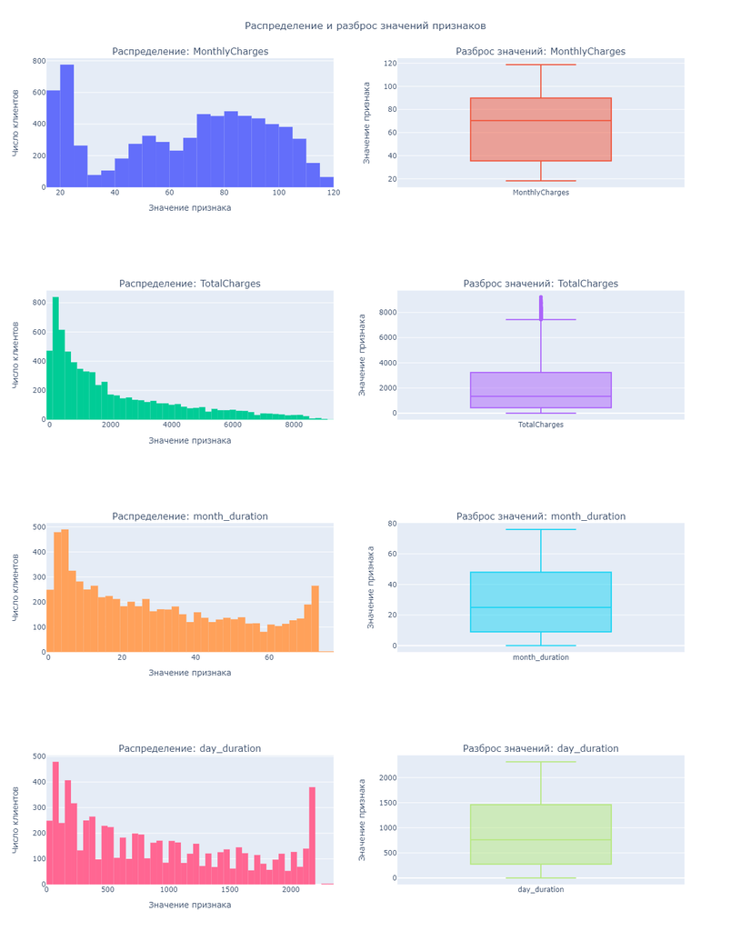

```python
num_cols = contract.drop([ 'left'], axis=1).select_dtypes(include='number').columns
hist_and_box_for_nums_plotly(contract, num_cols)
```

```python
def hist_for_nums(data, cols):
    for col, ax in zip(cols, axs.ravel()):
        sns.histplot(data = data[col], bins = 50, ax=ax)
        ax.set_title(col)
        ax.set_xlabel(col)
        ax.set_ylabel('Число клиентов')
def box_for_nums(data, cols):
    for col, ax in zip(cols, axs.ravel()):
        sns.boxplot(data = data[col].values, ax=ax)
        ax.set_title(col)
        ax.set_ylabel(col)
```

## 3.2 **Даты**

Посмотрим за какой период данные.

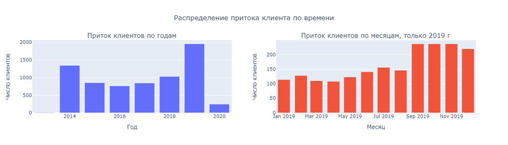

```python
fig = make_subplots(rows=1, cols=2, subplot_titles=['Приток клиентов по годам', 'Приток клиентов по месяцам, только 2019 г'])
fig.add_trace(go.Bar(x=pd.DatetimeIndex(contract['BeginDate']).year.value_counts().index, y=pd.DatetimeIndex(contract['BeginDate']).year.value_counts().values), row=1, col=1)
fig.add_trace(go.Bar(x=contract[pd.DatetimeIndex(contract['BeginDate']).year == 2019].BeginDate.value_counts().index,
                     y=contract[pd.DatetimeIndex(contract['BeginDate']).year == 2019].BeginDate.value_counts().values), row=1, col=2)
fig.update_layout({'title': {'text':"Распределение притока клиента по времени", 'x':0.5}}, showlegend=False)
fig.update_yaxes(title_text = 'Число клиентов')
fig.update_xaxes(title_text='Год', row=1, col=1)
fig.update_xaxes(title_text='Месяц', row=1, col=2)
```

Работаем с данными по клиентам которые пришли в компанию с 2013 по 2020 годы. При этом больше всего клиентов пришло в 2019 и 2014 году.

Если отдельно рассмотреть ушедших клиентов, то увидим, что:

- большая из часть стала клиентами компании в 2014-2015 гг
- покидали компанию в основном в 2018-2019 гг и в основном после 1-3 лет пользования услушами компании

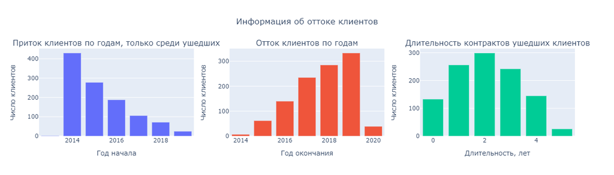

```python
contracts_left = contract[contract['left'] == 1]
fig = make_subplots(rows=1, cols=3, subplot_titles=['Приток клиентов по годам, только среди ушедших', 'Отток клиентов по годам', 'Длительность контрактов ушедших клиентов'])
fig.add_trace(go.Bar(x=pd.DatetimeIndex(contracts_left['BeginDate']).year.value_counts().index, y=pd.DatetimeIndex(contracts_left['BeginDate']).year.value_counts().values), row=1, col=1)
fig.add_trace(go.Bar(x=pd.DatetimeIndex(contracts_left['EndDate_all']).year.value_counts().index,
                     y=pd.DatetimeIndex(contracts_left['EndDate_all']).year.value_counts().values), row=1, col=2)
fig.add_trace(go.Bar(x=contracts_left['year_duration'].value_counts().index,
                     y=contracts_left['year_duration'].value_counts().values), row=1, col=3)
fig.update_layout({'title': {'text':"Информация об оттоке клиентов", 'x':0.5}}, showlegend=False)
fig.update_yaxes(title_text = 'Число клиентов')

fig.update_xaxes(title_text='Год начала', row=1, col=1)
fig.update_xaxes(title_text='Год окончания', row=1, col=2)
fig.update_xaxes(title_text='Длительность, лет', row=1, col=3)
```

## 3.3 **Категориальные признаки**

```python
def count_for_cat(data, columns, cols_subplots=2):
    cols_subplots = cols_subplots
    rows = (len(columns) + cols_subplots - 1) // cols_subplots
    fig = make_subplots(rows=rows, cols=cols_subplots, subplot_titles=[f'Распределение: {col}' for col in columns])
    for i, col in enumerate(columns):
        row = (i // cols_subplots) + 1
        colmn = (i % cols_subplots) + 1
        fig.add_trace(go.Bar(x=(data[col].value_counts(normalize=True)*100).index, y=(data[col].value_counts(normalize=True)*100).values), row=row, col=colmn)

    fig.update_layout(height=400*rows,title_text='Распределение категориальных признаков', title_x=0.5, showlegend = False)
    fig.update_yaxes(title_text="Доля клиентов, %")
    fig.update_xaxes(title_text="Значение признака")
    if 'left' in columns:
        fig.update_xaxes(tickvals=["0", "1"],ticktext=["No", "Yes"], row=2, col=2)
    if 'SeniorCitizen' in columns:
        fig.update_xaxes(tickvals=["0", "1"],ticktext=["No", "Yes"], row=1, col=2)
    if 'InternetService' in columns:
        fig.update_xaxes(tickvals=["No", "Yes"],ticktext=["Not applied", "Applied"])
        fig.update_xaxes(tickvals=(data['InternetService'].value_counts(normalize=True)*100).index, ticktext= (data['InternetService'].value_counts(normalize=True)*100).index,  row=1,col=1)


    fig.show()
```

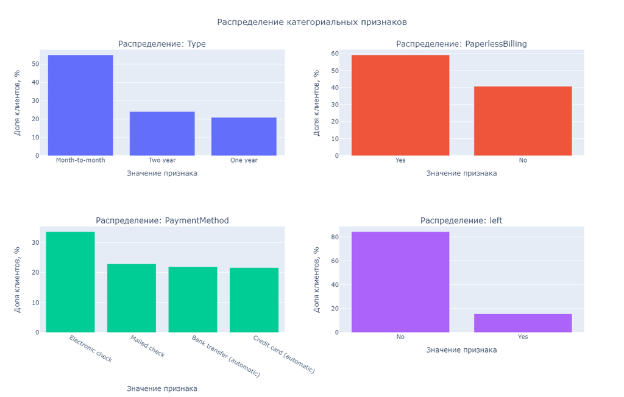

```python
cat_cols = contract.drop(['EndDate', 'BeginDate', 'EndDate_all', 'year_duration' ], axis=1).select_dtypes(exclude='number').columns
count_for_cat(contract, cat_cols)
```

- Большинство клиентов оплачивает услуги компании ежемесячно.
- Чуть больше половины клиентов получают электронный расчетный лист и с помощью него оплачивают услуги. У 44% клиентов подкючен автоплатеж.
- В датасете присутствует дисбаланс по целевому классу: только 16% от всех клиентов перестали пользоваться услугами компании.

```python
personal.sample()
```

| customerID | gender | SeniorCitizen | Partner | Dependents |
| --- | --- | --- | --- | --- |
| 5708-EVONK | Female | 0 | Yes | Yes |

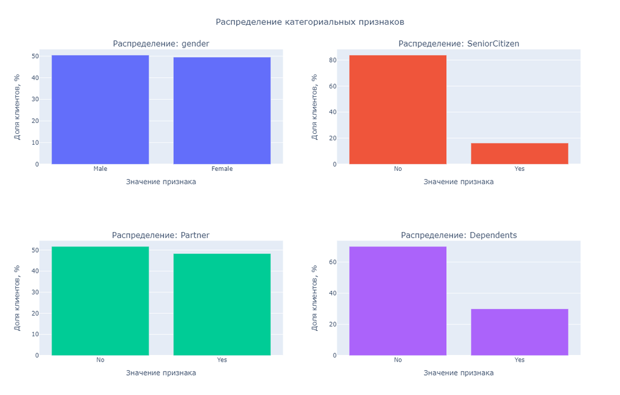

```python
cat_cols = personal.select_dtypes(exclude='number').columns
count_for_cat(personal, cat_cols)
```

- Среди клиентов равное количество мужчин и женщин, в браке и нет.
- Клиенты, в основном, не являются пенсионерами и не имеют детей.

```python
phone.sample()
```

| customerID | MultipleLines |
| --- | --- |
| 1697-NVVGY | No |

```python
internet.sample()
```

| customerID | InternetService | OnlineSecurity | OnlineBackup | DeviceProtection | TechSupport | StreamingTV | StreamingMovies |
| --- | --- | --- | --- | --- | --- | --- | --- |
| 4636-JGAAI | Fiber optic | No | Yes | No | No | No | Yes |

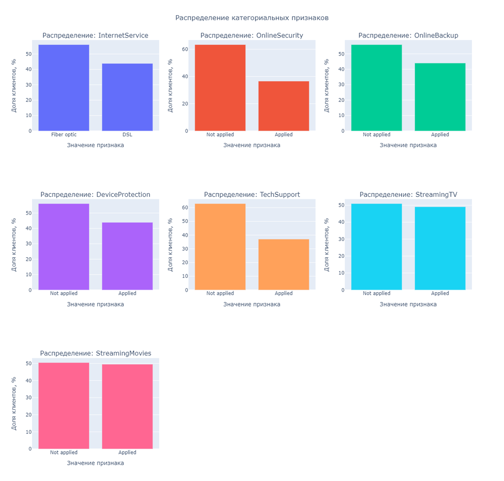

```python
cat_cols = internet.select_dtypes(exclude='number').columns

count_for_cat(internet, cat_cols, cols_subplots=3)
```

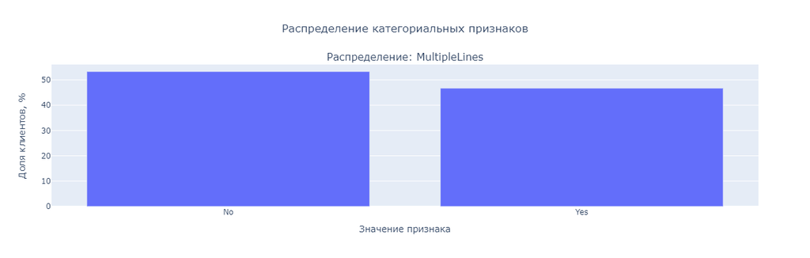

```python
cat_cols = phone.select_dtypes(exclude='number').columns

count_for_cat(phone, cat_cols, cols_subplots=1)
```

Касаемо подключенных услуг:

- около 60% клиентов подключили интернет через оптоволокно
- клиенты довольно активно пользуются дополнительными интрнет-услугами. Примерно 40% клиентов пользуются той или иной услугой (антивирус, облако, блокировка опасных сайтов, вип поддержка). Примерно половина клиентов подключило стриминговое тв или католог фильмов.
- Почти половина клиентов имеет подключение к нескольким телефонным линиям одновременно

## 3.4 Вывод по EDA

# 4. Объединение таблиц и анализ общей таблицы

## 4.1 Объединение

```python
total = personal.merge(contract, on = 'customerID', how = 'inner').merge(internet, on = 'customerID', how = 'left').merge(phone, on = 'customerID', how = 'left')
total.shape
```

```
(7043, 24)
```

```python
total.sample(3)
```

| customerID | gender | SeniorCitizen | Partner | Dependents | BeginDate | EndDate | Type | PaperlessBilling | PaymentMethod | MonthlyCharges | TotalCharges | EndDate_all | year_duration | month_duration | day_duration | left | InternetService | OnlineSecurity | OnlineBackup | DeviceProtection | TechSupport | StreamingTV | StreamingMovies | MultipleLines |
| --- | --- | --- | --- | --- | --- | --- | --- | --- | --- | --- | --- | --- | --- | --- | --- | --- | --- | --- | --- | --- | --- | --- | --- | --- |
| 8849-PRIQJ | Female | 0 | Yes | Yes | 2014-07-01 | 2016-06-01 | One year | Yes | Electronic check | 109.40 | 2516.2 | 2016-06-01 | 1 | 23 | 701 | 1 | Fiber optic | Yes | No | Yes | Yes | Yes | Yes | Yes |
| 5244-IRFIH | Male | 1 | Yes | No | 2017-01-01 | No | Month-to-month | Yes | Electronic check | 94.50 | 3496.5 | 2020-02-01 | 3 | 37 | 1126 | 0 | Fiber optic | No | No | No | No | Yes | Yes | Yes |
| 4412-YLTKF | Female | 1 | No | No | 2017-10-01 | No | Month-to-month | Yes | Electronic check | 78.05 | 2185.4 | 2020-02-01 | 2 | 28 | 853 | 0 | Fiber optic | No | No | Yes | No | No | No | Yes |

```python
total.info()
```

```
<class 'pandas.core.frame.DataFrame'>
Index: 7043 entries, 7590-VHVEG to 3186-AJIEK
Data columns (total 24 columns):
 #   Column            Non-Null Count  Dtype
---  ------            --------------  -----
 0   gender            7043 non-null   object
 1   SeniorCitizen     7043 non-null   object
 2   Partner           7043 non-null   object
 3   Dependents        7043 non-null   object
 4   BeginDate         7043 non-null   object
 5   EndDate           7043 non-null   object
 6   Type              7043 non-null   object
 7   PaperlessBilling  7043 non-null   object
 8   PaymentMethod     7043 non-null   object
 9   MonthlyCharges    7043 non-null   float64
```

[output cut: 16 more lines]

Объединенная таблица готова, все 7043 клиента на месте.

Заменим пропуски специальной категорией,у тех кто пользуется только интрнетом или только телефоном от оператора.

```python
total.MultipleLines = total.MultipleLines.fillna('NO_phone')

int_col = [internet.columns]

for col in int_col:
    total[col]= total[col].fillna('NO_internet')
```

```python
total.info()
```

```
<class 'pandas.core.frame.DataFrame'>
Index: 7043 entries, 7590-VHVEG to 3186-AJIEK
Data columns (total 24 columns):
 #   Column            Non-Null Count  Dtype
---  ------            --------------  -----
 0   gender            7043 non-null   object
 1   SeniorCitizen     7043 non-null   object
 2   Partner           7043 non-null   object
 3   Dependents        7043 non-null   object
 4   BeginDate         7043 non-null   object
 5   EndDate           7043 non-null   object
 6   Type              7043 non-null   object
 7   PaperlessBilling  7043 non-null   object
 8   PaymentMethod     7043 non-null   object
 9   MonthlyCharges    7043 non-null   float64
```

[output cut: 16 more lines]

## 4.2 Разведочный анализ с делением по целевому признаку

- количественные показатели

```python
num_cols = total.select_dtypes(include='number').columns
num_cols
```

```
Index(['MonthlyCharges', 'TotalCharges', 'month_duration', 'day_duration'], dtype='object')
```

```python
def hist_for_classes_plotly(df, col, bins=50):

    class_0 = df[df['left'] == 0][col]
    class_1 = df[df['left'] == 1][col]


    trace1 = go.Histogram(x=class_1, nbinsx=bins, name='ушли', opacity=0.75, histnorm='probability density')
    trace2 = go.Histogram(x=class_0, nbinsx=bins, name='остались', opacity=0.75, histnorm='probability density')

    fig = go.Figure(data=[trace1, trace2])

    fig.update_layout(title_text=col, title_x=0.5,
                      xaxis_title_text=col,
                      yaxis_title_text='Плотность',
                      barmode='overlay')
    fig.update_traces(opacity=0.6)

    fig.show()
```

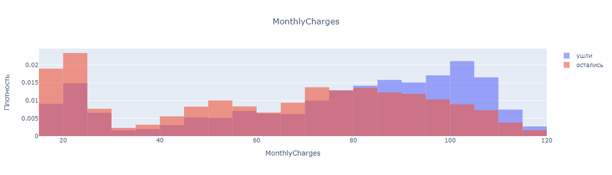

```python
hist_for_classes_plotly(total,'MonthlyCharges')
```

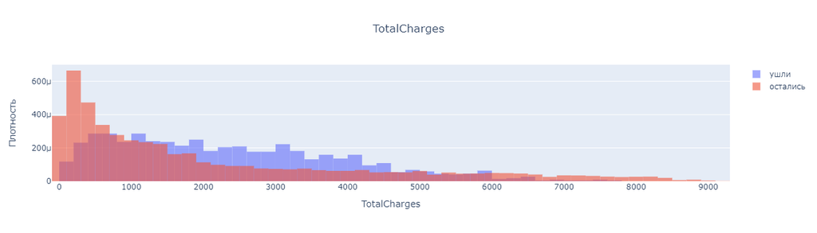

```python
hist_for_classes_plotly(total, 'TotalCharges')
```

Расходы ушедших клиентов слегка выше, чем у оставшихся. Вероятно из-за того, что среди не расторгнувших договор достаточно много новых клиентов, которые пришли меньше года назад.

- категориальные признаки

```python
def count_for_classes(data, columns, cols_subplots=2):
    cols_subplots = cols_subplots
    rows = (len(columns) + cols_subplots - 1) // cols_subplots
    fig = make_subplots(rows=rows, cols=cols_subplots, subplot_titles=[f'Распределение: {col}' for col in columns])
    for i, col in enumerate(columns):
        row = (i // cols_subplots) + 1
        colmn = (i % cols_subplots) + 1

        colors = {0:'steelblue',
          1:'firebrick'}
        if i==0:
          for t in data['left'].unique():
            dfp = data[data['left']==t]
            fig.add_trace(go.Bar(x=(dfp[col].value_counts(normalize=True)*100).index, y=(dfp[col].value_counts(normalize=True)*100).values, name = 'ушли' if t == 1 else 'остались',
                          marker_color=colors[t]), row=row, col=colmn)
        else:
           for t in data['left'].unique():
            dfp = data[data['left']==t]
            fig.add_trace(go.Bar(x=(dfp[col].value_counts(normalize=True)*100).index, y=(dfp[col].value_counts(normalize=True)*100).values,name=t,
                          marker_color=colors[t], showlegend=False), row=row, col=colmn)

        if col == 'SeniorCitizen':
          fig.update_xaxes(tickvals=["0", "1"],ticktext=["No", "Yes"], row=row, col=colmn)
        if col in ['OnlineSecurity', 'OnlineBackup', 'DeviceProtection', 'TechSupport',
       'StreamingTV', 'StreamingMovies']:
          fig.update_xaxes(tickvals=["No", "Yes", 'NO_internet'],ticktext=["Not applied", "Applied", 'no internet service'], row=row, col=colmn)
        if col == 'MultipleLines':
          fig.update_xaxes(tickvals=["No", "Yes", 'NO_phone'],ticktext=["Not applied", "Applied", 'no phone service'], row=row, col=colmn)


    fig.update_layout(height=400*rows,title_text='Распределение категориальных признаков в классах', title_x=0.5, showlegend = True)
    fig.update_yaxes(title_text="Доля клиентов, %")
    fig.update_xaxes(title_text="Значение признака")
    fig.update_xaxes(title_text="Длительность контракта, лет", row=4, col=2)

    fig.show()
```

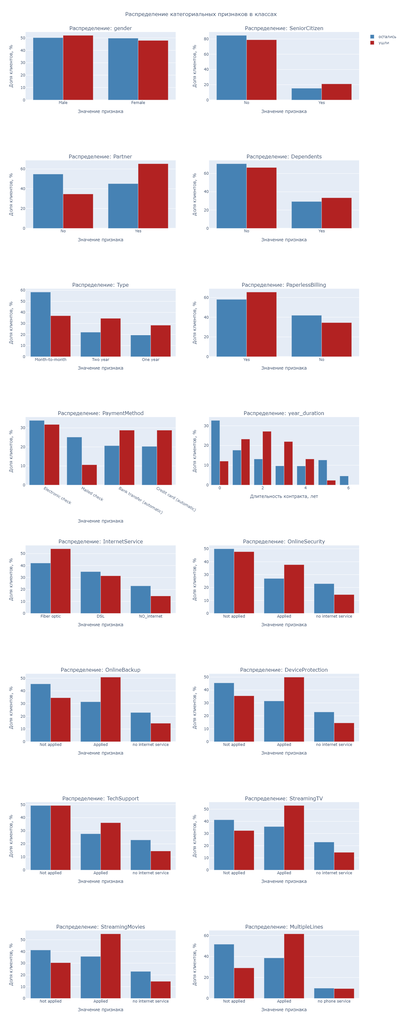

```python
cat_cols = total.drop(['left', 'BeginDate', 'EndDate', 'EndDate_all'], axis=1).select_dtypes(exclude='number').columns

count_for_classes(total, cat_cols)
```

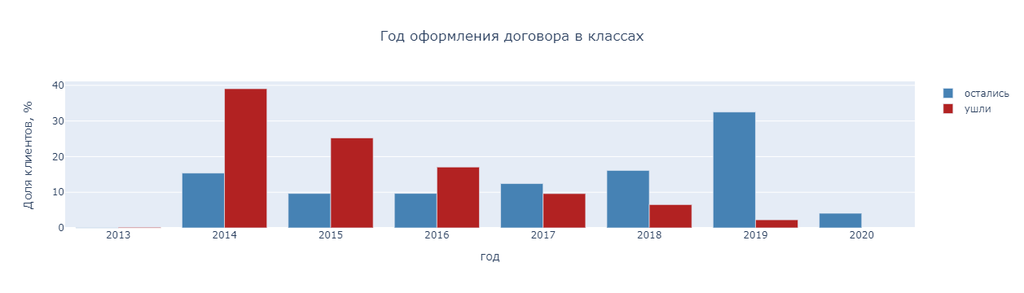

```python
fig = go.Figure()
colors = {0:'steelblue',
          1:'firebrick'}
for t in total['left'].unique():
    dfp = total[total['left']==t]
    fig.add_trace(go.Bar(x=(pd.DatetimeIndex(dfp['BeginDate']).year.value_counts(normalize=True)*100).index, y=(pd.DatetimeIndex(dfp['BeginDate']).year.value_counts(normalize=True)*100).values, name = 'ушли' if t == 1 else 'остались',
                        marker_color=colors[t]))
fig.update_layout(title_text='Год оформления договора в классах', title_x=0.5, showlegend = True)
fig.update_yaxes(title_text="Доля клиентов, %")
fig.update_xaxes(title_text="год")
fig.show()
```

Различия "портретов" ушедшего клиента и оставшегося клиента компании:

- Более половины ушедших клиентов состоят в браке ( среди оставшихся - больше одиноких)
- Ушедшие клиенты относительно меньше пользовались расчетом по почте нежеди действующие клиенты.
- Ушедшие клиенты активнее пользовались доп интернет услугами (облако, антивирус, стриминговое тв, каталог фильмов)
- Ушедшие клиенты активнее пользовались услугой подключения нескольких телефонных линий

Ушли, в основном, старые клиенты.

Среди оставшихся клиентов много новых , которые пришли около года назад или меньше.

## 4.3 Корреляции признаков

```python
corr_matrix1 = total.drop(columns=['BeginDate', 'EndDate', 'EndDate_all']) \
.phik_matrix(interval_cols=['MonthlyCharges', 'TotalCharges', 'month_duration', 'day_duration'])
```

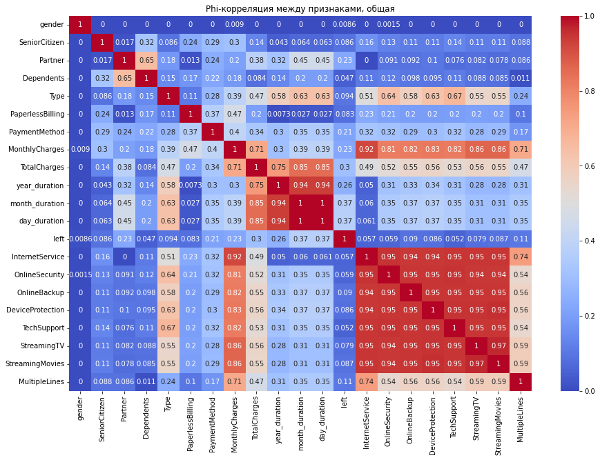

```python
plt.figure(figsize=(15, 10))
sns.heatmap(corr_matrix1, annot=True, cmap='coolwarm')
plt.title('Phi-корреляция между признаками, общая')
plt.show();
```

С целевым признаком остальные признаки коррелируют умеренно или слабо.

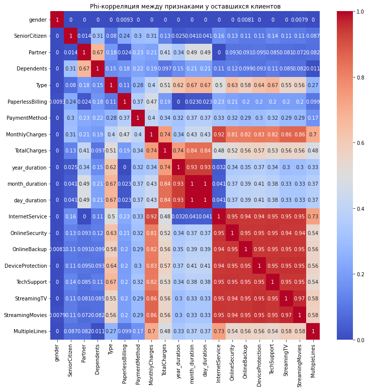

```python
corr_matrix = total[total['left']==0].drop(columns=['BeginDate', 'EndDate', 'EndDate_all']) \
.phik_matrix(interval_cols=['MonthlyCharges', 'TotalCharges', 'month_duration', 'day_duration'])

plt.figure(figsize=(12,12))
sns.heatmap(corr_matrix, annot=True, cmap='coolwarm')
plt.title('Phi-корреляция между признаками у оставшихся клиентов')
plt.show();
```

В подгруппе оставшихся клиентов:

- Все интернет услуги сильно коррелируют друг с другом - мультиколлинеарны.
- Длительность договора в днях и месяцах тоже мультиколлинеарны, очевидно
- Пол клиента никак не связан с остальными признаками (стоит убрать из исследования).
- Расходы коррелируют с наличием подключенных услуг: очевидно, чем больше подключено услуг, тем больше расходы клиента.

```python
total.sample()
```

| customerID | gender | SeniorCitizen | Partner | Dependents | BeginDate | EndDate | Type | PaperlessBilling | PaymentMethod | MonthlyCharges | TotalCharges | EndDate_all | year_duration | month_duration | day_duration | left | InternetService | OnlineSecurity | OnlineBackup | DeviceProtection | TechSupport | StreamingTV | StreamingMovies | MultipleLines |
| --- | --- | --- | --- | --- | --- | --- | --- | --- | --- | --- | --- | --- | --- | --- | --- | --- | --- | --- | --- | --- | --- | --- | --- | --- |
| 1644-IRKSF | Female | 0 | Yes | Yes | 2017-01-01 | 2018-05-01 | One year | Yes | Electronic check | 93.8 | 1635.87 | 2018-05-01 | 1 | 16 | 485 | 1 | Fiber optic | No | No | Yes | No | Yes | Yes | No |

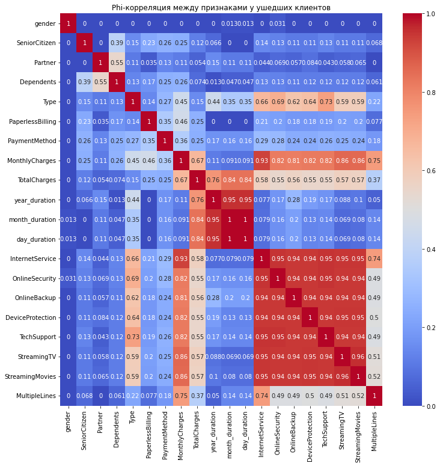

```python
corr_matrix1 = total[total['left']==1].drop(columns=['BeginDate', 'EndDate', 'EndDate_all']) \
.phik_matrix(interval_cols=['MonthlyCharges', 'TotalCharges', 'month_duration', 'day_duration'])
plt.figure(figsize=(12, 12))
sns.heatmap(corr_matrix1, annot=True, cmap='coolwarm')
plt.title('Phi-корреляция между признаками у ушедших клиентов')
plt.show();
```

Для класса ушедших клиентов характерны все выше описанные закономерности для первого класса.

## 4.4 Вывод

1. Все четыре таблицы соединили в одну.
2. Проанализировали данные по группам (ушел / не ушел клиент):
- Расходы ушедших клиентов слегка выше, чем у оставшихся. Вероятно из-за того, что среди не расторгнувших договор достаточно много новых клиентов, которые пришли меньше года назад.
- Различия "портретов" ушедшего клиента и оставшегося клиента компании:
  - Более половины ушедших клиентов состоят в браке ( среди оставшихся - больше одиноких)
  - Ушедшие клиенты относительно меньше пользовались расчетом по почте нежеди действующие клиенты.
  - Ушедшие клиенты активнее пользовались доп интернет услугами (облако, антивирус, стриминговое тв, каталог фильмов)
  - Ушедшие клиенты активнее пользовались услугой подключения нескольких телефонных линий
- Ушли, в основном, старые клиенты.
- Среди оставшихся клиентов много новых , которые пришли около года назад или меньше.
1. Корреляции:
- С целевым признаком остальные признаки коррелируют слабо.
- Все интернет услуги сильно коррелируют друг с другом - мультиколлинеарны.
- Пол клиента никак не связан с остальными признаками (стоит убрать дальше из исследования).
- Расходы коррелируют с наличием подключенных услуг: очевидно, чем больше подключено услуг, тем больше расходы клиента.

# 5. Подготовка данных и обучение моделей

Необходимо решить задачу классификации.

Таргет - признак `left`, ушел клиент или остался.

В качестве входных признаков будем использовать не все. Уберем даты, пол клиента.

При подготовке данных для линейной модели уберем все мультиколлинеарные признаки (из всех интернет услуг оставим только `InternetService`).

Количественные данные масштабируем с помощью StandardScaler. Для категориальных признаков применим OHE для не "деревянных" моделей. Для моделей в основе которых лежат деревья - OrdinalEncoder.

Будем работать через пайплайны.

Оценим качество разбиения на классы с помощью ROC-AUC для классификаторов логистической регрессии, дерева решений, SVC, KNN, lightgbm и выберем лучшую (самую точную) модель.

**Критерий успеха: ROC-AUC ≥0.85 на тестовой выборке.** Дополнительно будем использовать accuracy для удобства интерпретации точности модели.

## 5.1 Базовая модель - логистическая регрессия

```python
total['year_duration'] = total['year_duration'].astype(int)
drop_cols = ['gender', 'BeginDate', 'EndDate','EndDate_all', 'left', 'month_duration',
             'OnlineSecurity','OnlineBackup', 'DeviceProtection', 'TechSupport', 'StreamingTV', 'StreamingMovies']

total['left'] = total['left'].astype(int)

X = total.drop(columns = drop_cols)
y = total.left
X_train, X_test, y_train, y_test = train_test_split(X, y, test_size=0.25, stratify = y, random_state=RANDOM_STATE)
```

```python
X_train.shape
```

```
(5282, 12)
```

```python
num_columns = X.select_dtypes(include='number').columns
ohe_columns = X.select_dtypes(exclude='number').columns
print(num_columns)
print(ohe_columns)
```

```
Index(['MonthlyCharges', 'TotalCharges', 'year_duration', 'day_duration'], dtype='object')
Index(['SeniorCitizen', 'Partner', 'Dependents', 'Type', 'PaperlessBilling',
       'PaymentMethod', 'InternetService', 'MultipleLines'],
      dtype='object')
```

```python
data_preprocessor = ColumnTransformer(
    [
        ('ohe', OneHotEncoder(drop='first', handle_unknown='ignore'), ohe_columns),
        ('num', StandardScaler(), num_columns)
    ],
    remainder='passthrough'
)
```

```python
pipe_final = Pipeline(
    [   ('preprocessor', data_preprocessor),
     ('selection', SelectKBest(k = 10)),
        ('models', LogisticRegression(random_state=RANDOM_STATE))
    ]
)
```

```python
pipe_final.fit(X_train, y_train)

print(f'Roc-Auc модели: {cross_val_score(pipe_final,X_train, y_train, cv =StratifiedKFold(), scoring = "roc_auc" ).mean()}')

print(f'Точность модели: {cross_val_score(pipe_final,X_train, y_train, cv =StratifiedKFold(), scoring = "accuracy" ).mean()}')
```

```
Roc-Auc модели: 0.7220519511583591
Точность модели: 0.8436199148533585
```

Хороший результат для базовой логистической регрессии!

## 5.2 Подбор лучшей модели

Попробуем улучшить линейную модель:

```python
param_distributions = {'models__C': fl(0.1, 2.0, 0.1),
                       'selection__k': intd(5,15),
        'preprocessor__num': CatDist((StandardScaler(), MinMaxScaler(), 'passthrough'))}

optuna_search = OptunaSearchCV(
pipe_final,
param_distributions=param_distributions,
scoring='roc_auc',
random_state=RANDOM_STATE,
cv=StratifiedKFold(),
n_jobs=-1,
)
optuna_search.fit(X_train, y_train)

print('Метрика для лучшей модели:\n', round(optuna_search.best_score_,4))
print('\nЛучшая модель и её параметры:\n\n', optuna_search.best_estimator_)
```

[output not shown]

[output cut: 188 more lines]

[output not shown]

```
Метрика для лучшей модели:
 0.7661

Лучшая модель и её параметры:

 Pipeline(steps=[('preprocessor',
                 ColumnTransformer(remainder='passthrough',
                                   transformers=[('ohe',
                                                  OneHotEncoder(drop='first',
                                                                handle_unknown='ignore'),
                                                  Index(['SeniorCitizen', 'Partner', 'Dependents', 'Type', 'PaperlessBilling',
       'PaymentMethod', 'InternetService', 'MultipleLines'],
      dtype='object')),
                                                 ('num', StandardScaler(),
                                                  Index(['MonthlyCharges', 'TotalCharges', 'year_duration', 'day_duration'], dtype='object'))])),
                ('selection', SelectKBest(k=13)),
                ('models',
                 LogisticRegression(C=0.257219870271167, random_state=180324))])
```

Качество слегка улучшилось. Попробуем с другими моделями.

Будем варьировать как модели, так и используемые для обучение признаки, чтобы добиться лучшей метрики.

Чтобы легко менять используемые в обучении признаки, создадим функцию для подготовки данных и обучения.

```python
def prepare_n_learn(data, drop_columns,param_distributions):
    '''
    Функция принимает на вход исходный датасет, список признаков для удаления (включая таргет и ID),
    гиперпараметры для подбора модели в виде списка словарей.
    Сначала выделяется таргет и входные признаки,
    затем выборка делится на трейн и тест. \Затем происходит кодировка таргета, кодировка признаков в пайплайне.
    Формируетмя итоговый пайплайн для обучения.
    Возвращает качество ROC-AUC, параметры лучшей модели после подбора гиперпараметров в ходе RandomizedSearchCV и тестовые выборки
    '''
    y = data.left
    X = data.drop(columns = drop_columns)
    num_columns = X.select_dtypes(include ='number').columns
    cat_columns = X.select_dtypes(exclude ='number').columns

    X[cat_columns] = X[cat_columns].astype('category')

    X_train, X_test, y_train, y_test = train_test_split(X, y, test_size=0.25, stratify = y, random_state=RANDOM_STATE)

    data_preprocessor = ColumnTransformer(
    [
        ('cat', OneHotEncoder(drop='first', handle_unknown='ignore'), cat_columns),
        ('num', StandardScaler(), num_columns)
    ],
    remainder='passthrough'
    )

    pipe_final = Pipeline(
    [
        ('preprocessor', data_preprocessor),
        ('selection', SelectKBest(k = 19)),
        ('models', DecisionTreeClassifier(random_state=RANDOM_STATE))
    ]
    )


    randomized_search = RandomizedSearchCV(
    pipe_final,
    param_distributions=param_distributions,
    scoring='roc_auc',
    random_state=RANDOM_STATE,
    cv=StratifiedKFold(),
    n_jobs=-1,
    n_iter = 50
    )
    randomized_search.fit(X_train, y_train)

    return round(randomized_search.best_score_,4), randomized_search.best_estimator_, X_test, y_test
```

```python
drop_columns = [ 'gender', 'BeginDate', 'EndDate','EndDate_all', 'left', 'month_duration', 'day_duration']
ord_pipe = Pipeline([(
            'ord',
            OrdinalEncoder(handle_unknown='use_encoded_value', unknown_value=np.nan)
        ),
        (
            'imputer_after',
            SimpleImputer(missing_values=np.nan, strategy='most_frequent')
        )])

param_distributions = [

        {'models': [DecisionTreeClassifier(random_state=RANDOM_STATE)],
        'models__max_depth': range(2, 10),
        'models__min_samples_split': range(2, 10),
        'preprocessor__cat': [ord_pipe],
        'preprocessor__num': [StandardScaler(), MinMaxScaler(), 'passthrough'],
        'selection__k': range(15,20),
        } ,

        {'models': [lgb.LGBMClassifier(random_state=RANDOM_STATE)],
        'models__learning_rate': np.arange(0.01, 0.3, 0.02),
        'models__max_depth': range(2,4),
        'models__n_estimators': range(80,160, 20) ,
        'preprocessor__cat': [ord_pipe],
        'preprocessor__num': [StandardScaler(), MinMaxScaler(), 'passthrough'],
        'selection__k': range(15,20),
        } ,

        {'models': [KNeighborsClassifier()],
         'models__n_neighbors': range(3, 20),
         'preprocessor__num': [StandardScaler(), MinMaxScaler(), 'passthrough'],
          'selection__k': range(15,20),
          },

        {'models': [SVC(random_state=RANDOM_STATE, probability=True)],
        'models__kernel': ['rbf', 'poly', 'sigmoid'],
        'models__degree': range(2, 5),
        'preprocessor__num': [StandardScaler(), MinMaxScaler(), 'passthrough'],
         'selection__k': range(15,20),
         }

    ]

best_score, best_model, X_test, y_test = prepare_n_learn(total, drop_columns,param_distributions)

print('Метрика для лучшей модели:\n', best_score)
print('\nЛучшая модель и её параметры:\n\n', best_model)
```

```
[LightGBM] [Info] Number of positive: 826, number of negative: 4456
[LightGBM] [Info] Auto-choosing row-wise multi-threading, the overhead of testing was 0.000626 seconds.
You can set `force_row_wise=true` to remove the overhead.
And if memory is not enough, you can set `force_col_wise=true`.
[LightGBM] [Info] Total Bins 556
[LightGBM] [Info] Number of data points in the train set: 5282, number of used features: 17
[LightGBM] [Info] [binary:BoostFromScore]: pavg=0.156380 -> initscore=-1.685412
[LightGBM] [Info] Start training from score -1.685412
Метрика для лучшей модели:
 0.8324

Лучшая модель и её параметры:

 Pipeline(steps=[('preprocessor',
                 ColumnTransformer(remainder='passthrough',
                                   transformers=[('cat',
                                                  Pipeline(steps=[('ord',
                                                                   OrdinalEncoder(handle_unknown='use_encoded_value',
                                                                                  unknown_value=nan)),
                                                                  ('imputer_after',
                                                                   SimpleImputer(strategy='most_frequent'))]),
                                                  Index(['SeniorCitizen', 'Partner', 'Dependents', 'Type', 'PaperlessBilling',
       'PaymentMethod', 'InternetServi...neBackup',
       'DeviceProtection', 'TechSupport', 'StreamingTV', 'StreamingMovies',
       'MultipleLines'],
      dtype='object')),
                                                 ('num', MinMaxScaler(),
                                                  Index(['MonthlyCharges', 'TotalCharges', 'year_duration'], dtype='object'))])),
                ('selection', SelectKBest(k=17)),
                ('models',
                 LGBMClassifier(learning_rate=0.06999999999999999, max_depth=2,
                                n_estimators=120, random_state=180324))])
```

Получилось улучшить метрику. Однако пока она все еще не соответствует критерию качества.

Может быть длительность контракта в годах недостаточно информативна? Попробуем добавить длительность в днях и месяцах.

```python
drop_columns = [ 'gender', 'BeginDate', 'EndDate','EndDate_all', 'left',]

best_score, best_model, X_test, y_test = prepare_n_learn(total, drop_columns,param_distributions)
```

[output not shown]

[output cut: 15 more lines]

[output not shown]

```python
print('Метрика для лучшей модели:\n', best_score)
print('\nЛучшая модель и её параметры:\n\n', best_model)
```

```
Метрика для лучшей модели:
 0.882

Лучшая модель и её параметры:

 Pipeline(steps=[('preprocessor',
                 ColumnTransformer(remainder='passthrough',
                                   transformers=[('cat',
                                                  Pipeline(steps=[('ord',
                                                                   OrdinalEncoder(handle_unknown='use_encoded_value',
                                                                                  unknown_value=nan)),
                                                                  ('imputer_after',
                                                                   SimpleImputer(strategy='most_frequent'))]),
                                                  Index(['SeniorCitizen', 'Partner', 'Dependents', 'Type', 'PaperlessBilling',
       'PaymentMethod', 'InternetServi...
       'DeviceProtection', 'TechSupport', 'StreamingTV', 'StreamingMovies',
       'MultipleLines'],
      dtype='object')),
                                                 ('num', StandardScaler(),
                                                  Index(['MonthlyCharges', 'TotalCharges', 'year_duration', 'month_duration',
       'day_duration'],
      dtype='object'))])),
                ('selection', SelectKBest(k=19)),
                ('models',
                 LGBMClassifier(learning_rate=0.26999999999999996, max_depth=3,
                                n_estimators=140, random_state=180324))])
```

Добавление длительности контракта в днях и месяцах помогло. Метрика ROC-AUC сильно увеличилась и полученная модель соответсвует критерию качества.

Посмотрим качество на тестовой выборке:

```python
print(f'ROC-AUC на тесте: {roc_auc_score(y_test, best_model.predict_proba(X_test)[:,1] )}')
print(f'Точность на тесте: {accuracy_score(y_test,  best_model.predict(X_test))}')
```

```
ROC-AUC на тесте: 0.8993686528814387
Точность на тесте: 0.8932424758659853
```

Хорошее, походящее под критерий значение метрики ROC-AUC на тестовой выборке!

Точность (accuracy) тоже довольно высокое. Значение 0.9 показывает, что 9 из 10 клиентов модель классифицирует верно.

#### **Посмотрим на матрицу ошибок:**

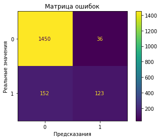

```python
cm = confusion_matrix(y_test, best_model.predict(X_test))
ConfusionMatrixDisplay(cm, display_labels=best_model['models'].classes_).plot()
plt.title('Матрица ошибок')
plt.xlabel('Предсказания')
plt.ylabel('Реальные значения')
plt.show()
```

#### Проверим модель на **адекватность** с помощью DummyClassifier:

```python
drop_columns
```

```
['gender', 'BeginDate', 'EndDate', 'EndDate_all', 'left']
```

```python
X = total.drop(columns = drop_columns)
y = total.left

X_train, X_test, y_train, y_test = train_test_split(X, y, test_size=0.25, stratify = y, random_state=RANDOM_STATE)

pipe_dummy = Pipeline(
    [
        ('preprocessor', data_preprocessor),
        ('models', DummyClassifier(strategy="prior"))
    ]
)
```

```python
pipe_dummy.fit(X_train, y_train)

roc_auc_score(y_test, pipe_dummy.predict_proba(X_test)[:, 1])
```

```
0.5
```

Значение ROC-AUC DummyClassifier хуже, чем в лучшем классификаторе.

## 5.4 Анализ важности признаков

Оценим какие признаки и как влияют на классификацию склонных к уходу клиентов.

```python
ord =  OrdinalEncoder(handle_unknown='use_encoded_value', unknown_value=np.nan)
cat_columns = X_train.select_dtypes(exclude ='number').columns
X_train_processed = ord.fit_transform(X_train[cat_columns])
```

```python
cat_columns_ext = list(cat_columns)
cat_columns_ext.extend(['MonthlyCharges', 'TotalCharges', 'year_duration', 'month_duration',
       'day_duration'])
```

```python
cat_columns_ext
```

```
['SeniorCitizen',
 'Partner',
 'Dependents',
 'Type',
 'PaperlessBilling',
 'PaymentMethod',
 'InternetService',
 'OnlineSecurity',
 'OnlineBackup',
 'DeviceProtection',
 'TechSupport',
 'StreamingTV',
 'StreamingMovies',
 'MultipleLines',
 'MonthlyCharges',
 'TotalCharges',
 'year_duration',
 'month_duration',
 'day_duration']
```

```python
classifier = best_model["models"]
X_train_processed = best_model["preprocessor"].transform(X_train)
X_train_processed = pd.DataFrame(X_train_processed, columns=cat_columns_ext)

X_test_processed = best_model["preprocessor"].transform(X_test)
X_test_processed = pd.DataFrame(X_test_processed, columns=cat_columns_ext)
```

```python
X_test_processed.sample()
```

|  | SeniorCitizen | Partner | Dependents | Type | PaperlessBilling | PaymentMethod | InternetService | OnlineSecurity | OnlineBackup | DeviceProtection | TechSupport | StreamingTV | StreamingMovies | MultipleLines | MonthlyCharges | TotalCharges | year_duration | month_duration | day_duration |
| --- | --- | --- | --- | --- | --- | --- | --- | --- | --- | --- | --- | --- | --- | --- | --- | --- | --- | --- | --- |
| 1501 | 0.0 | 1.0 | 1.0 | 2.0 | 0.0 | 1.0 | 2.0 | 0.0 | 0.0 | 0.0 | 0.0 | 0.0 | 0.0 | 1.0 | -1.498736 | -0.787502 | -0.553079 | -0.2904 | -0.288754 |

```python
explainer = shap.KernelExplainer(classifier.predict_proba, X_train_processed.sample(200))
```

```
Using 200 background data samples could cause slower run times. Consider using shap.sample(data, K) or shap.kmeans(data, K) to summarize the background as K samples.
```

```python
shap_values = explainer(X_test_processed[:30])
```

Посмотрим важность признаков, в целом:

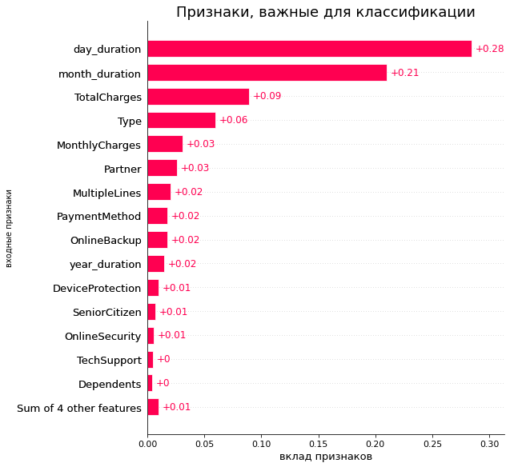

```python
fig, ax = plt.subplots()

shap.plots.bar(shap_values[:,:,1], max_display=16, show=False)
ax.set_xlabel('вклад признаков')
ax.set_ylabel('входные признаки')
ax.set_title('Признаки, важные для классификации', fontsize=18)
```

Определяющим фактором в поиске клиентов,склонных разорвать контракт с компанией, является длительность договора.

Кроме того, не последнюю роль в определении класса клиента играют тип оплаты (помесячно, ежегодно, раз в два года), расходы, наличие партнера.

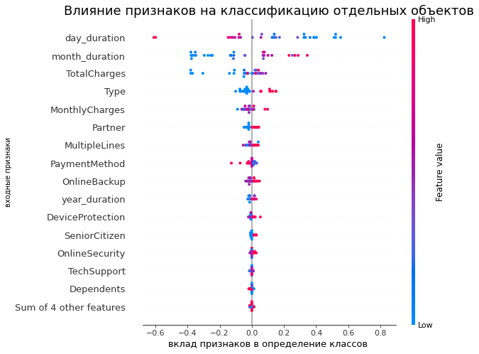

```python
fig, ax = plt.subplots()

shap.plots.beeswarm(shap_values[:,:,1], max_display=16, show=False)
ax.set_xlabel('вклад признаков в определение классов ')
ax.set_ylabel('входные признаки')
ax.set_title('Влияние признаков на классификацию отдельных объектов', fontsize=18);
```

Клиент склонен разорвать договор с компанией, если:

- это "старый" клиент. Вероятно, т.к. компания не дает привелегии для лояльных клиентов, такой клиент перестает пользоваться невыгодной услугой. Может перейти к другому оператору, который предлагает бонусы новым клиентам.
- в тоже время это могут быть и новые клиенты. Видимо таким клиентам тоже оператор дает недостаточно выгодное предложение.
- клиенты с оплатой раз в год, раз в два года. Может быть, такой тип оплаты в целом не очень перспективный, т.к. в связи с довольно быстрым темпом развития цифровых услуг, услуги в течение 1-2 лет могут устаревать (например, скорость интернета), а клиент должен ждать следующего периода оплаты, чтоб что-то поменять или оказывается в другой подобной невыгодной ситуации.
- семейный клиенты. Такие клиенты могут жестче контролировать свои расходы, поэтому могут уйти от оператора к более выгодному.

## 5.5 Вывод по обучению

За счет использования нелинейной модели - модели градиентного бустинга lightgbm - и изменения признаков используемых при обучении удалось достичь желаемого качества модели. Для обучения использовали, все данные, кроме пола клиентов, дат начала и окончания договора. В том числе использовали созданные признаки длительности договора (в днях, месяцах и годах), что помогло значительно повысить метрику качества.

Согласно анализу важности признаков:

- Определяющим фактором в поиске клиентов,склонных разорвать контракт с компанией, является длительность договора.
- Кроме того, не последнюю роль в определении класса клиента играют тип оплаты (помесячно, ежегодно, раз в два года), расходы, наличие партнера.

Клиент склонен разорвать договор с компанией, если:

- это "старый" клиент. Вероятно, компания не дает привелегии для лояльных клиентов
- в тоже время это могут быть и новые клиенты. Видимо таким клиентам тоже оператор дает недостаточно выгодное предложение.
- клиенты с оплатой раз в год, раз в два года.
- семейный клиенты. Такие клиенты могут жестче контролировать свои расходы, поэтому могут уйти от оператора к более выгодному.

# 6. Итоговый вывод

1. **Обзор данных:**
- Информация для исследования представлена в 4 таблицах (данные договоров, персональные данные клиентов, информация о интернет услугах и услугах телефонии). Данные соответствуют описанию задачи.
- Всего для исследования предоставлены данные 7043 клиентов компании, некоторые пользуются только интернет услугами, другие - услугами телефонии.
- Есть клиенты, которые только начали пользоваться услугами компании - договор от 1 февраля 2020 (дата выгрузки данных).
1. **Предобработка данных:**
- Обнаружено небольшое количество пропусков в таблице с контрактами в колонке общих расходов.Пропуски характерные для клиентов, которые только оформили договор и еще ничего не заплатили. Таких записей 11 штук. Пропуски преобразовали в нули.
- Дубликатов не обнаружено.
- Изменила тип данных колонки, является ли клиент пенсионером, - на категориальный тип; колонки общих расходов - на вещественный числовой.
- Добавила целевой признак (1 - клиент ушел, 0 - клиент остался), а также вспомогателные признаки с длительностью контракта (в годах, в днях и в месяцах) для всех клиентов.
1. **Предварительный разведочный анализ:**
- Для работы предоставлены данные по клиентам которые пришли в компанию с 2013 по 2020 годы. При этом больше всего клиентов пришло в 2019 и 2014 году.
- Много относительно новых клиентов - в компании около 10-20 недель. Есть локальный максимум "старых" клиентов - пользуются услугами компании около 70 месяцев (более пяти лет).
- "Усредненного" клиента можно описать так:
  - небольшое количество подключенных услуг, отсюда небольшие месячные расходы
  - оплачивает услуги компании ежемесячно, оплата по электронному расчетному листу или подключен автоплатеж
  - моложе пенсионного возраста, без детей
  - если пользуется интернет услугами, то подключение через оптоволокно, вероятно подключены доп услуги (стриминговое ТВ и др).
- В датасете присутствует дисбаланс по целевому классу: только 16% от всех клиентов перестали пользоваться услугами компании. Это умеренный дисбаланс, ничего предпринимать для его устранения не будем (кроме того, что учтем это при разбиении выборок).
- При отдельном рассмотрении ушедших клиентов видим, что:
  - большая их часть стала клиентами компании в 2014-2015 гг
  - покидали компанию в основном в 2018-2019 гг
  - разрывали контракт после 1-3 лет пользования услугами оператора
1. **Объединение таблиц и разведочный анализ:**
- Все четыре таблицы соединили в одну по идентификатору клиента.
- Проанализировали данные по группам (ушел / не ушел клиент):

  a. Расходы ушедших клиентов слегка выше, чем у оставшихся. Вероятно из-за того, что среди не расторгнувших договор достаточно много новых клиентов, которые пришли меньше года назад, а среди ушедших, наоборот, много "старых" клиентов.

  b. Различия "портретов" ушедшего клиента и оставшегося клиента компании:
  - Более половины ушедших клиентов состоят в браке ( среди оставшихся - больше одиноких)
  - Ушедшие клиенты относительно меньше пользовались расчетом по почте нежеди действующие клиенты.
  - Ушедшие клиенты активнее пользовались доп интернет услугами (облако, антивирус, стриминговое тв, каталог фильмов)
  - Ушедшие клиенты активнее пользовались услугой подключения нескольких телефонных линий
- Анализ корреляций показал, что:
  - С целевым признаком остальные признаки коррелируют умеренно или слабо.
  - Все интернет услуги сильно коррелируют друг с другом - мультиколлинеарны.
  - Пол клиента никак не связан с остальными признаками (стоит убрать дальше из исследования).
  - Расходы коррелируют с наличием подключенных услуг: очевидно, чем больше подключено услуг, тем больше расходы клиента.
1. **Обучение моделей**

За счет использования нелинейной модели - модели градиентного бустинга lightgbm - и изменения признаков используемых при обучении удалось достичь желаемого качества модели. Для обучения использовали, все данные, кроме пола клиентов, дат начала и окончания договора. В том числе использовали созданные признаки длительности договора (в днях, месяцах и годах), что помогло значительно повысить метрику качества.

Согласно анализу важности признаков:

- Определяющим фактором в поиске клиентов,склонных разорвать контракт с компанией, является длительность договора.
- Кроме того, не последнюю роль в определении класса клиента играют тип оплаты (помесячно, ежегодно, раз в два года), расходы, наличие партнера.

Клиент склонен разорвать договор с компанией, если:

- это "старый" клиент. Вероятно, т.к. компания не дает привелегии для лояльных клиентов, такой клиент перестает пользоваться невыгодной услугой. Может перейти к другому оператору, который предлагает бонусы новым клиентам.
- в тоже время это могут быть и новые клиенты. Видимо таким клиентам тоже оператор дает недостаточно выгодное предложение.
- клиенты с оплатой раз в год, раз в два года. Может быть, такой тип оплаты в целом не очень перспективный, т.к. в связи с довольно быстрым темпом развития цифровых услуг, услуги в течение 1-2 лет могут устаревать (например, скорость интернета), а клиент должен ждать следующего периода оплаты, чтоб что-то поменять или оказывается в другой подобной невыгодной ситуации.
- семейный клиенты. Такие клиенты могут жестче контролировать свои расходы, поэтому могут уйти от оператора к более выгодному.

**Рекомендации:**

- предлагать промокоды и различные бонусы клиентам:
  - которых модель классифицировала как склонных к уходу
  - лояльным клиентам, которые более двух лет пользуются услугами компании
  - новым клиентам, которые пользуются услугами пару месяцев
- вероятно, убрать режими оплаты раз в год и раз в два года
- разработать выгодные предложения для семейных клиентов